# Matching Striae in Bullets Follow-up

Eric Hare, Heike Hofmann, Alicia Carriquiry

April 19, 2016

# Goal

- We wish to determine whether two bullets were fired from the same gun barrel
- Striation patterns are unique to barrels and fairly stable
- Forensic Examiners shoot bullets from guns of suspects, compare it to bullet from crime scene

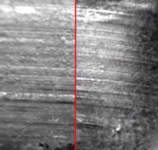

# James Hamby Study

- Ten consecutively rifled Ruger P-85 pistol barrels used to fire 20 “known” test bullets and 15 “unknown” bullets for comparison
- Sets of 35 bullets sent to 507 Forensic Examiners for examination
- 0 false positive identifications, 8 inconclusive results (out of 7605)

# Procedure

# Identifying Grooves (Easy)

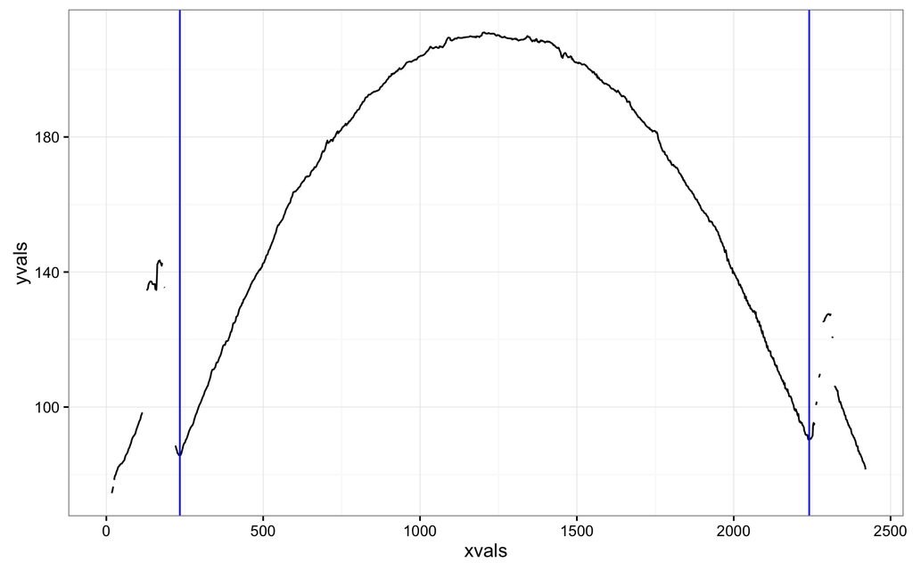

```r
result <- get_grooves(get_crosscut("~/GitHub/imaging-paper/app/images/Hamby252_3DX3P1of2/Br1 Bullet 1-2.x3p"))
result$plot
```

# Identifying Grooves (Challenging)

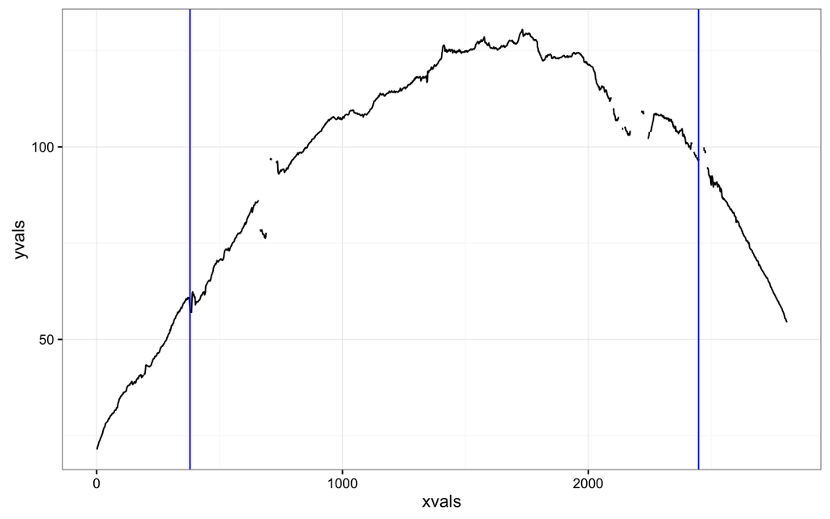

```r
result2 <- get_grooves(get_crosscut("~/GitHub/imaging-paper/app/images/Hamby252_3DX3P1of2/Br1 Bullet 1-6.x3p"))
result2$plot
```

# Improvements Made - Crosscut location

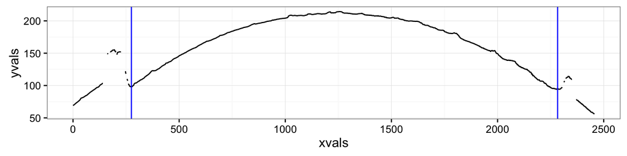

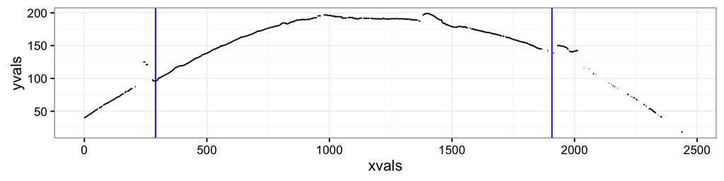

# Improvements Made - Mean Profile

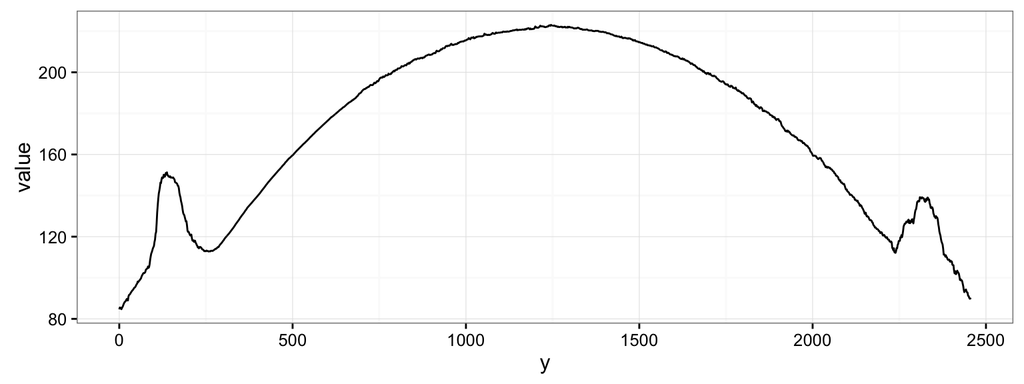

```r
mybullet <- fortify_x3p(read.x3p("~/GitHub/imaging-paper/app/images/Hamby252_3DX3P1of2/Br1 Bullet 1-4.x3p"))
mean.bullet <- mybullet %>%
    group_by(y) %>%
    summarise(value = mean(value, na.rm = TRUE))
qplot(y, value, data = mean.bullet, geom = "line") + theme_bw()
```

# Reminder: List of Features

- Maximal number of CMS (consecutive matching striae), and, similarly, the number of consecutively non-matching striae (CNMS),
- Number of matches and non-matches,
- Average difference $D$ between signatures, defined as the Euclidean vertical distance between surface measurements of aligned signatures.
  $$D^2 = \frac{1}{\text{\#}t}\sum_t \left[f(t) - g(t)\right]^2,$$
- The sum $S$ of average absolute heights of matched extrema
- Cross Correlation Function (CCF)

# Question: Which features depend on the length of the signature?

# Improvement: Scaling Features

Scale each feature dependent on the length by the length of the signature

- CMS per micrometer
- Matches per micrometer
- …
- Also include the length of the signature as a feature

# Improvements: Web Application

https://erichare.shinyapps.io/x3prproto

# Future Work from Before

- *We are extremely limited by data here - Currently we’ve only assessed this algorithm on one particular set of 35 bullets* (We now have 70 bullets! Huzzah!)
- *There is likely an effect from the equipment used to scan the bullets, or the person performing the scan* There is - The new set looks very different
- *We need to assess the quality of the algorithm in case we don’t have full bullet lands available, as is the case in many forensics applications* In progress!

# Thank You

Any Questions?